# Upscaling power analysis

## Background

The purpose of these simulations is to determine the conditions under which we are likely to find a difference between the MW and LS version of a variable. The two measures are likely to be highly correlated (in our example, the two measures have a correlation coefficient of 0.97) and therefore it is important that we understand this. We are still able to detect the difference between the two approaches because of a large sample size characteristic of macroecological approaches. However, in order to understand wider applicability - and under which circumstances the method is applicable - we will do a simulation to determine, for a given correlation coefficient, at what sample size do you no longer have the ability to detect an effect.

Will need to think about this for a range of R, a range of n, and also whether there is a change if you introduce a third variable. We will also need to consider different types of effects (what if there is no effect of LS, but effect of MW, or vice versa? or opposite effects).

Note that while this shows us the conditions under which we are able to detect the differing effects of two correlated variables, I don’t believe that it tells us about *when* we should use the MW approach over the LS approach. My argument would be that in general the MW approach should be preferred because this is a more mechanistic way of measuring landscape structure. The useful information these simulations provide is the sample size / correlation coefficient combinations under which one can detect the individual effects of two correlated variables. This is useful for those wishing to include both measures in their analysis. Recommendation would be that if the power does not exist to detect this difference, to include only the MW version.

## Predictors

In order to do this, we simulated several sets of predictors of varying sample size and correlation. For each pair of correlated predictors, we also generated a third independent predictor. We therefore have a set of predictors *X* where $x_1$ and $x_2$ are correlated, and $x_3$ is independent. The changing parameters in the dataset simulations were:

```r
n <- c(30, 50, 100, 250, 500, 750, 1000, 2000, 5000)
r <- c(0.7, 0.75, 0.8, 0.85, 0.9, 0.95)
rep <- 1:params$n_reps

param_table <- expand.grid(n = n, r = r, rep = rep)

res <- apply(param_table, 1, function(p) {
  n = p['n']
  r = p['r']
  rep = p['rep']
  z <- mapply(rnorm, n, rep(0, 3), rep(1, 3))
  x <- corr_pair(z[,1:2], r)
  out <- data.frame(n, r, rep, x, z[,3], row.names = NULL)
  names(out) <- c("n", "r", "rep","x1", "x2", "x3")
  return(out)
})

pred_df <- ldply(res)
```

## Responses

In order to understand how this differs between models, we will generate response variables for each dataset for the following models:

- $y = 0.5x_1 + \epsilon$ - only one variable has an effect
- $y = 0.5x_1 + 0.5x_2 + \epsilon$ - two correlated variables, same effect
- $y = 0.5x_1 - 0.5x_2 + \epsilon$ - two correlated variables, opposite effect
- $y = 0.5x_1 + 0.5x_3 + \epsilon$ - two uncorrelated variables (similar to jay)
- $y = 0.5x_1 + 0.5x_2 + 0.5x_3 + \epsilon$ - two correlated variables, same effect, plus third independent variable
- $y = 0.5x_1 - 0.5x_2 + 0.5x_3 + \epsilon$ - two correlated variables, opposite effect, plus third independent variable (similar to forests)

In each case here $\epsilon$ has a normal error structure $\epsilon\sim N(0, params$noise)$. We currently do not consider interaction terms in these simulations. We may wish to extend this and include these, and/or look at variable effect sizes. I’m not sure either are really necessary.

```r
df <- pred_df %>%
  mutate(y1 = 0.5*x1 + rnorm(n, 0, params$noise),
         y2 = 0.5*x1 + 0.5*x2 + rnorm(n, 0, params$noise),
         y3 = 0.5*x1 - 0.5*x2 + rnorm(n, 0, params$noise),
         y4 = 0.5*x1 + 0.5*x3 + rnorm(n, 0, params$noise),
         y5 = 0.5*x1 + 0.5*x2 + 0.5*x3 + rnorm(n, 0, params$noise),
         y6 = 0.5*x1 - 0.5*x2 + 0.5*x3 + rnorm(n, 0, params$noise))
```

## Models

For $y_1$ to $y_3$, we fit a linear model of the form $y_i = \beta_1x_1 + \beta_2x_2 + \epsilon$. We should not get an effect of $x_2$ for the model fit to $y_1$, the effect should be identical for the model fit to $y_2$ and the effect should be opposite for the model fit to $y_3$.

For $y_4$ to $y_6$, we fit a linear model of the form $y_i = \beta_1x_1 + \beta_2x_2 + \beta_3x_3 + \epsilon$. Our expectations are as above, but with an effect of $x_3$ = 0.5.

```r
df_mod <- df %>% group_by(n, r, rep) %>%
  nest() %>%
  mutate(fit1 = map(data, ~ lm(y1 ~ x1 + x2, data = .x)),
         fit2 = map(data, ~ lm(y2 ~ x1 + x2, data = .x)),
         fit3 = map(data, ~ lm(y3 ~ x1 + x2, data = .x)),
         fit4 = map(data, ~ lm(y4 ~ x1 + x2 + x3, data = .x)),
         fit5 = map(data, ~ lm(y5 ~ x1 + x2 + x3, data = .x)),
         fit6 = map(data, ~ lm(y6 ~ x1 + x2 + x3, data = .x)),
         mod1 = map(fit1, tidy),
         mod2 = map(fit2, tidy),
         mod3 = map(fit3, tidy),
         mod4 = map(fit4, tidy),
         mod5 = map(fit5, tidy),
         mod6 = map(fit6, tidy)
  ) %>%
  select(n, r, rep, mod1, mod2, mod3, mod4, mod5, mod6) %>%
  gather(key = model, value = result, -n, -r, -rep) %>%
  unnest()
```

## Results

$y_1 = 0.5x_1 + \epsilon$

```r
df <- filter(df_mod, model == "mod1", term != "(Intercept)") %>%
  inner_join(data.frame(truth = c(0.5, 0), term = c("x1", "x2"))) %>%
  mutate(signif = case_when(truth == 0 & p.value < 0.05 ~ "Incorrect",
                            truth == 0 & p.value >= 0.05 ~ "Correct",
                            truth != 0 & p.value < 0.05 ~ "Correct",
                            truth != 0 & p.value >= 0.05 ~ "Incorrect"))
```

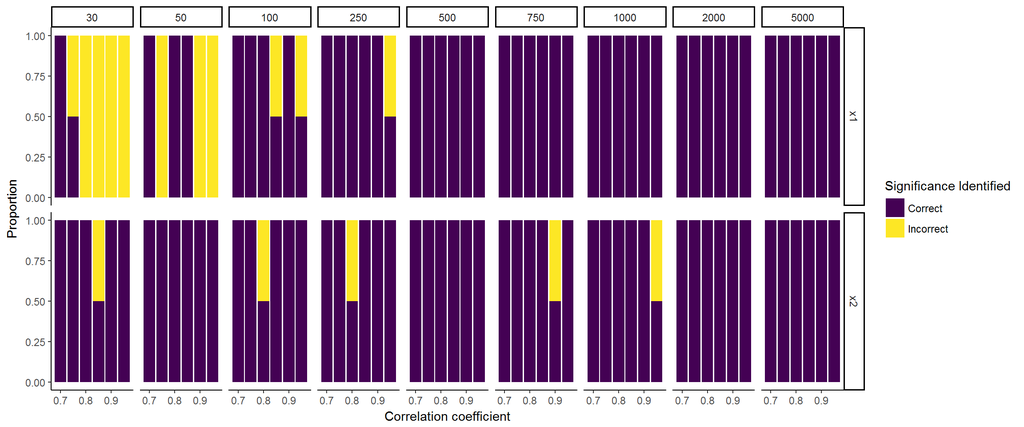

```r
mod_vals <- filter(df, signif == "Correct") %>%
  group_by(n, r, model, term, truth) %>%
  summarise(mean_estimate = mean(estimate),
            se_estimate = sd(estimate)/sqrt(n()))

mod_identified <- group_by(df, n, r, term, signif) %>%
  summarise(prop = n()/params$n_reps)

ggplot(mod_identified, aes(x = r, y = prop, fill = signif)) +
  geom_bar(stat = "identity") +
  scale_fill_viridis_d(name = "Significance Identified") +
  facet_grid(term ~ n) +
  labs(x = "Correlation coefficient", y = "Proportion")
```

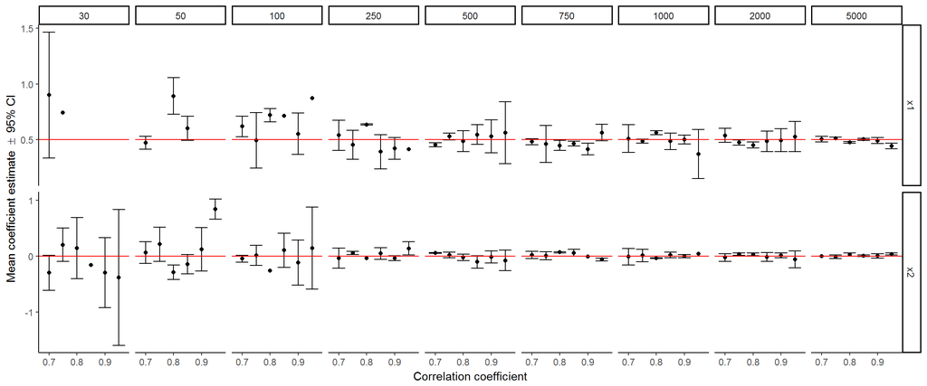

```r
ggplot(mod_vals, aes(x = r, y = mean_estimate)) +
  geom_point() +
  geom_errorbar(aes(ymin = mean_estimate - 1.96*se_estimate, ymax = mean_estimate + 1.96*se_estimate)) +
  facet_grid(term ~ n, scales = "free") +
  geom_hline(aes(yintercept = truth), colour = "red") +
  labs(x = "Correlation coefficient", y = expression(paste("Mean coefficient estimate " %+-% " 95% CI")))
```

$y = 0.5x_1 + 0.5x_2 + \epsilon$

```r
df <- filter(df_mod, model == "mod2", term != "(Intercept)") %>%
  inner_join(data.frame(truth = c(0.5, 0.5), term = c("x1", "x2"))) %>%
  mutate(signif = case_when(truth == 0 & p.value < 0.05 ~ "Incorrect",
                            truth == 0 & p.value >= 0.05 ~ "Correct",
                            truth != 0 & p.value < 0.05 ~ "Correct",
                            truth != 0 & p.value >= 0.05 ~ "Incorrect"))
```

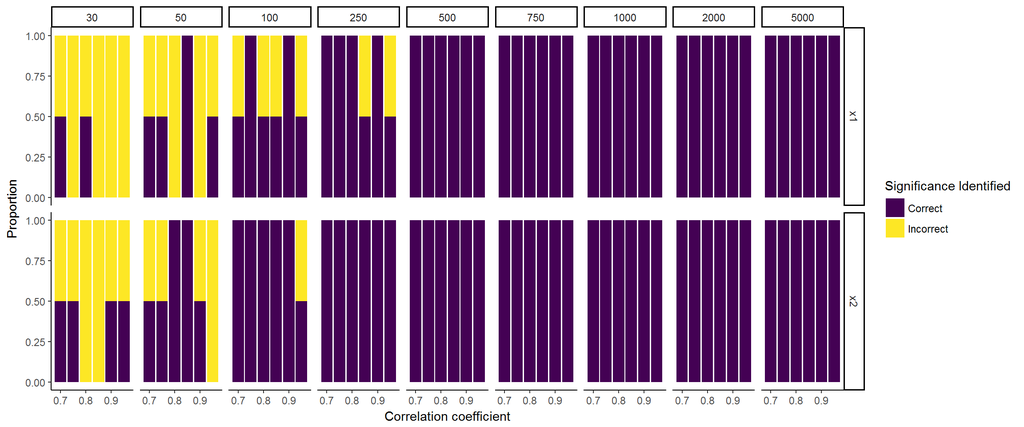

```r
mod_vals <- filter(df, signif == "Correct") %>%
  group_by(n, r, model, term, truth) %>%
  summarise(mean_estimate = mean(estimate),
            se_estimate = sd(estimate)/sqrt(n()))

mod_identified <- group_by(df, n, r, term, signif) %>%
  summarise(prop = n()/params$n_reps)

ggplot(mod_identified, aes(x = r, y = prop, fill = signif)) +
  geom_bar(stat = "identity") +
  scale_fill_viridis_d(name = "Significance Identified") +
  facet_grid(term ~ n) +
  labs(x = "Correlation coefficient", y = "Proportion")
```

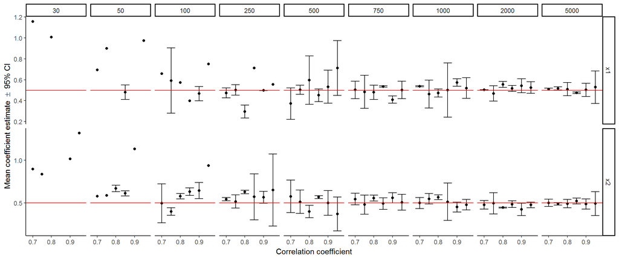

```r
ggplot(mod_vals, aes(x = r, y = mean_estimate)) +
  geom_point() +
  geom_errorbar(aes(ymin = mean_estimate - 1.96*se_estimate, ymax = mean_estimate + 1.96*se_estimate)) +
  facet_grid(term ~ n, scales = "free") +
  geom_hline(aes(yintercept = truth), colour = "red") +
  labs(x = "Correlation coefficient", y = expression(paste("Mean coefficient estimate " %+-% " 95% CI")))
```

$y = 0.5x_1 - 0.5x_2 + \epsilon$

```r
df <- filter(df_mod, model == "mod3", term != "(Intercept)") %>%
  inner_join(data.frame(truth = c(0.5, -0.5), term = c("x1", "x2"))) %>%
  mutate(signif = case_when(truth == 0 & p.value < 0.05 ~ "Incorrect",
                            truth == 0 & p.value >= 0.05 ~ "Correct",
                            truth != 0 & p.value < 0.05 ~ "Correct",
                            truth != 0 & p.value >= 0.05 ~ "Incorrect"))
```

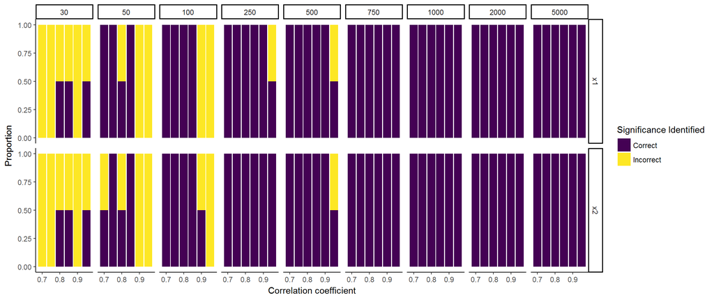

```r
mod_vals <- filter(df, signif == "Correct") %>%
  group_by(n, r, model, term, truth) %>%
  summarise(mean_estimate = mean(estimate),
            se_estimate = sd(estimate)/sqrt(n()))

mod_identified <- group_by(df, n, r, term, signif) %>%
  summarise(prop = n()/params$n_reps)

ggplot(mod_identified, aes(x = r, y = prop, fill = signif)) +
  geom_bar(stat = "identity") +
  scale_fill_viridis_d(name = "Significance Identified") +
  facet_grid(term ~ n) +
  labs(x = "Correlation coefficient", y = "Proportion")
```

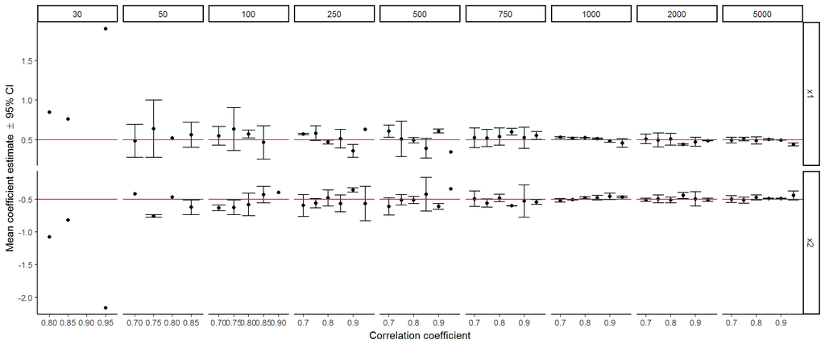

```r
ggplot(mod_vals, aes(x = r, y = mean_estimate)) +
  geom_point() +
  geom_errorbar(aes(ymin = mean_estimate - 1.96*se_estimate, ymax = mean_estimate + 1.96*se_estimate)) +
  facet_grid(term ~ n, scales = "free") +
  geom_hline(aes(yintercept = truth), colour = "red") +
  labs(x = "Correlation coefficient", y = expression(paste("Mean coefficient estimate " %+-% " 95% CI")))
```

$y = 0.5x_1 + 0.5x_3 + \epsilon$

```r
df <- filter(df_mod, model == "mod4", term != "(Intercept)") %>%
  inner_join(data.frame(truth = c(0.5, 0, 0.5), term = c("x1", "x2", "x3"))) %>%
  mutate(signif = case_when(truth == 0 & p.value < 0.05 ~ "Incorrect",
                            truth == 0 & p.value >= 0.05 ~ "Correct",
                            truth != 0 & p.value < 0.05 ~ "Correct",
                            truth != 0 & p.value >= 0.05 ~ "Incorrect"))
```

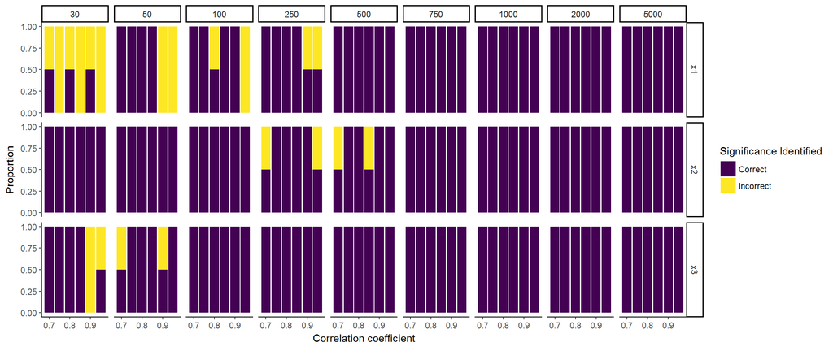

```r
mod_vals <- filter(df, signif == "Correct") %>%
  group_by(n, r, model, term, truth) %>%
  summarise(mean_estimate = mean(estimate),
            se_estimate = sd(estimate)/sqrt(n()))

mod_identified <- group_by(df, n, r, term, signif) %>%
  summarise(prop = n()/params$n_reps)

ggplot(mod_identified, aes(x = r, y = prop, fill = signif)) +
  geom_bar(stat = "identity") +
  scale_fill_viridis_d(name = "Significance Identified") +
  facet_grid(term ~ n) +
  labs(x = "Correlation coefficient", y = "Proportion")
```

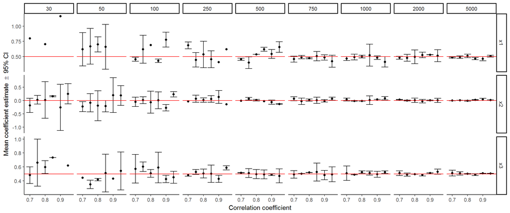

```r
ggplot(mod_vals, aes(x = r, y = mean_estimate)) +
  geom_point() +
  geom_errorbar(aes(ymin = mean_estimate - 1.96*se_estimate, ymax = mean_estimate + 1.96*se_estimate)) +
  facet_grid(term ~ n, scales = "free") +
  geom_hline(aes(yintercept = truth), colour = "red") +
  labs(x = "Correlation coefficient", y = expression(paste("Mean coefficient estimate " %+-% " 95% CI")))
```

$y = 0.5x_1 + 0.5x_2 + 0.5x_3 + \epsilon$

```r
df <- filter(df_mod, model == "mod5", term != "(Intercept)") %>%
  inner_join(data.frame(truth = c(0.5, 0.5, 0.5), term = c("x1", "x2", "x3"))) %>%
  mutate(signif = case_when(truth == 0 & p.value < 0.05 ~ "Incorrect",
                            truth == 0 & p.value >= 0.05 ~ "Correct",
                            truth != 0 & p.value < 0.05 ~ "Correct",
                            truth != 0 & p.value >= 0.05 ~ "Incorrect"))
```

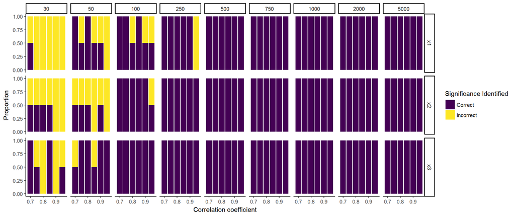

```r
mod_vals <- filter(df, signif == "Correct") %>%
  group_by(n, r, model, term, truth) %>%
  summarise(mean_estimate = mean(estimate),
            se_estimate = sd(estimate)/sqrt(n()))

mod_identified <- group_by(df, n, r, term, signif) %>%
  summarise(prop = n()/params$n_reps)

ggplot(mod_identified, aes(x = r, y = prop, fill = signif)) +
  geom_bar(stat = "identity") +
  scale_fill_viridis_d(name = "Significance Identified") +
  facet_grid(term ~ n) +
  labs(x = "Correlation coefficient", y = "Proportion")
```

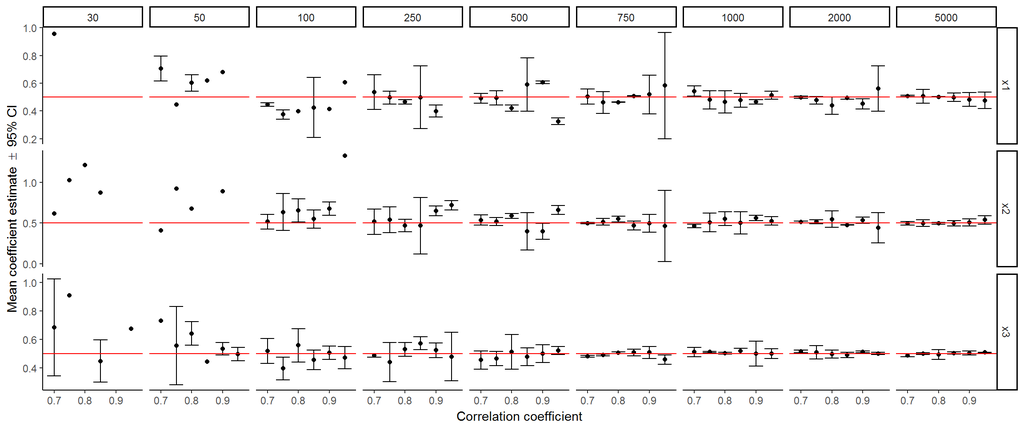

```r
ggplot(mod_vals, aes(x = r, y = mean_estimate)) +
  geom_point() +
  geom_errorbar(aes(ymin = mean_estimate - 1.96*se_estimate, ymax = mean_estimate + 1.96*se_estimate)) +
  facet_grid(term ~ n, scales = "free") +
  geom_hline(aes(yintercept = truth), colour = "red") +
  labs(x = "Correlation coefficient", y = expression(paste("Mean coefficient estimate " %+-% " 95% CI")))
```

$y = 0.5x_1 - 0.5x_2 + 0.5x_3 + \epsilon$

```r
df <- filter(df_mod, model == "mod6", term != "(Intercept)") %>%
  inner_join(data.frame(truth = c(0.5, -0.5, 0.5), term = c("x1", "x2", "x3"))) %>%
  mutate(signif = case_when(truth == 0 & p.value < 0.05 ~ "Incorrect",
                            truth == 0 & p.value >= 0.05 ~ "Correct",
                            truth != 0 & p.value < 0.05 ~ "Correct",
                            truth != 0 & p.value >= 0.05 ~ "Incorrect"))
```

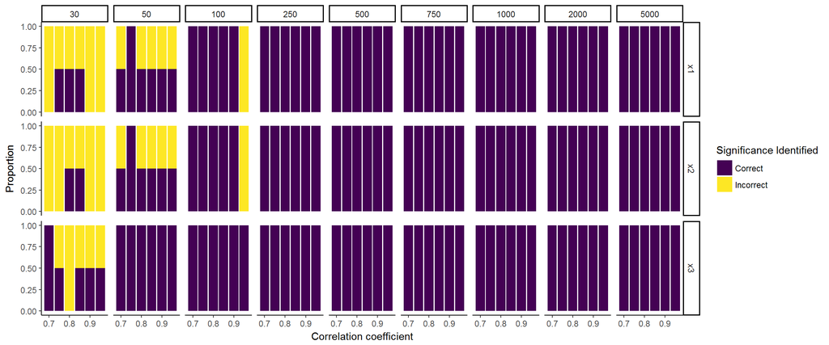

```r
mod_vals <- filter(df, signif == "Correct") %>%
  group_by(n, r, model, term, truth) %>%
  summarise(mean_estimate = mean(estimate),
            se_estimate = sd(estimate)/sqrt(n()))

mod_identified <- group_by(df, n, r, term, signif) %>%
  summarise(prop = n()/params$n_reps)

ggplot(mod_identified, aes(x = r, y = prop, fill = signif)) +
  geom_bar(stat = "identity") +
  scale_fill_viridis_d(name = "Significance Identified") +
  facet_grid(term ~ n) +
  labs(x = "Correlation coefficient", y = "Proportion")
```

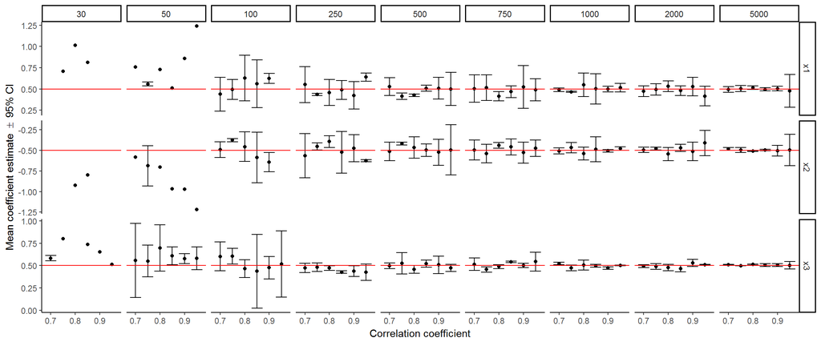

```r
ggplot(mod_vals, aes(x = r, y = mean_estimate)) +
  geom_point() +
  geom_errorbar(aes(ymin = mean_estimate - 1.96*se_estimate, ymax = mean_estimate + 1.96*se_estimate)) +
  facet_grid(term ~ n, scales = "free") +
  geom_hline(aes(yintercept = truth), colour = "red") +
  labs(x = "Correlation coefficient", y = expression(paste("Mean coefficient estimate " %+-% " 95% CI")))
```